# Week 11 Tutorial

ECON90033 - 2023 Semester 2

Josh Copeland

Completed on 16 October 2023

## Exercise 1

### a) Import the data file, plot the annual SR and LR interest rates in Australian from 1970 to 2021 and comment on the figures.

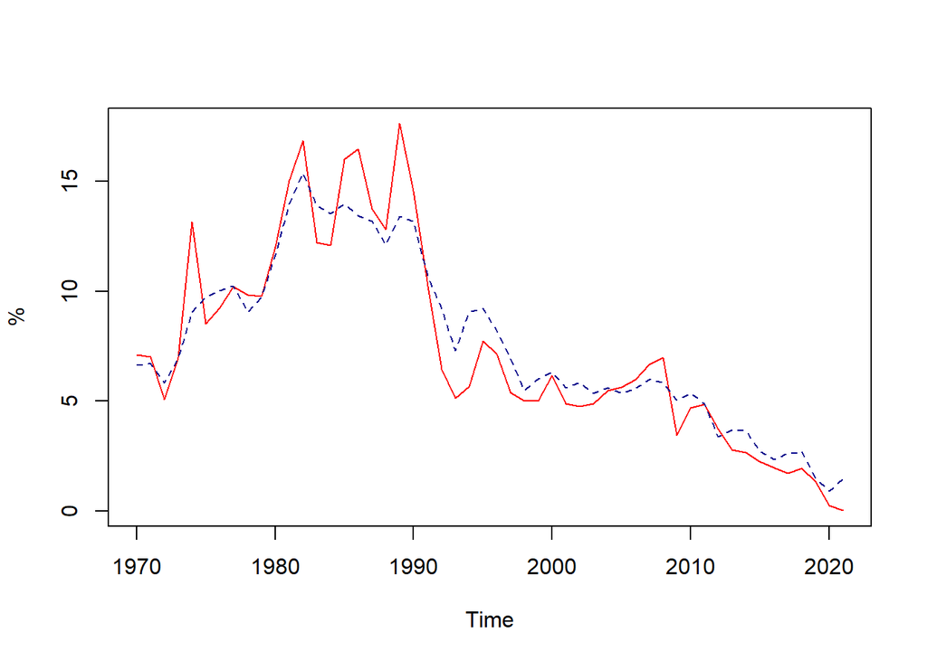

```r
e1 <- read_excel("C:/Users/joshc/Documents/2023S2/ECON90033/Tutorials/Week 11/t11e1.xlsx")


SR <- e1 %>%
  pull(SR) %>%
  ts(frequency = 1, start = 1970, end = 2021)

LR <- e1 %>%
  pull(LR) %>%
  ts(frequency = 1, start = 1970, end = 2021)

plot.ts(SR, ylab = "%", col = "red")
lines(LR, col = "darkblue", lty = 2)
```

### b) perform the ADF and KPSS tests on the level and first differences. What conclusions do you draw about the order of integration?

The time series plot suggest that both variables ought to use Model 3 and Model 2 in the tests for their levels and first differences respectively.

The results show:

- ADF:
  - For the levels, the null hypothesis of a unit root in maintained even at the 10% level. However, there are a few significant spikes in the residual correlograms. You can adjust the lags gradually, but ultimately we retain the same conclusion.
  - For the differences, we reject the null hypothesis of a unit root at the 1% significance level. There remains some 5th order serial correlation in the LR variable’s residuals.
- KPSS:
  - Same as ADF, we find evidence of a unit root in the level. For SR, we reject the null hypothesis of stationarity at the 5% significance level where we do the same for the LR at the 2.5% level.
  - We’re able to maintain the null hypothesis of no unit roots even at the 10% level for the differenced series for both variables.

Therefore, we’re able to conclude that these variables are stationary integrated at order 1.

```r
#library(urca)

#ADF tests

adf.SR <- ur.df(SR, type = "trend", selectlags = "BIC")
summary(adf.SR)
```

```
##
## ###############################################
## # Augmented Dickey-Fuller Test Unit Root Test #
## ###############################################
##
## Test regression trend
##
##
## Call:
## lm(formula = z.diff ~ z.lag.1 + 1 + tt + z.diff.lag)
##
## Residuals:
##     Min      1Q  Median      3Q     Max
## -5.1578 -0.7563 -0.1244  0.6773  5.8635
##
## Coefficients:
##             Estimate Std. Error t value Pr(>|t|)
## (Intercept)  4.08983    1.39930   2.923  0.00536 **
## z.lag.1     -0.27783    0.09484  -2.930  0.00527 **
## tt          -0.07949    0.02847  -2.792  0.00761 **
## z.diff.lag   0.07901    0.14131   0.559  0.57878
## ---
## Signif. codes:  0 '***' 0.001 '**' 0.01 '*' 0.05 '.' 0.1 ' ' 1
##
## Residual standard error: 2.022 on 46 degrees of freedom
## Multiple R-squared:  0.173,  Adjusted R-squared:  0.119
## F-statistic: 3.207 on 3 and 46 DF,  p-value: 0.03165
##
##
## Value of test-statistic is: -2.9296 3.2797 4.7952
##
## Critical values for test statistics:
##       1pct  5pct 10pct
## tau3 -4.04 -3.45 -3.15
## phi2  6.50  4.88  4.16
## phi3  8.73  6.49  5.47
```

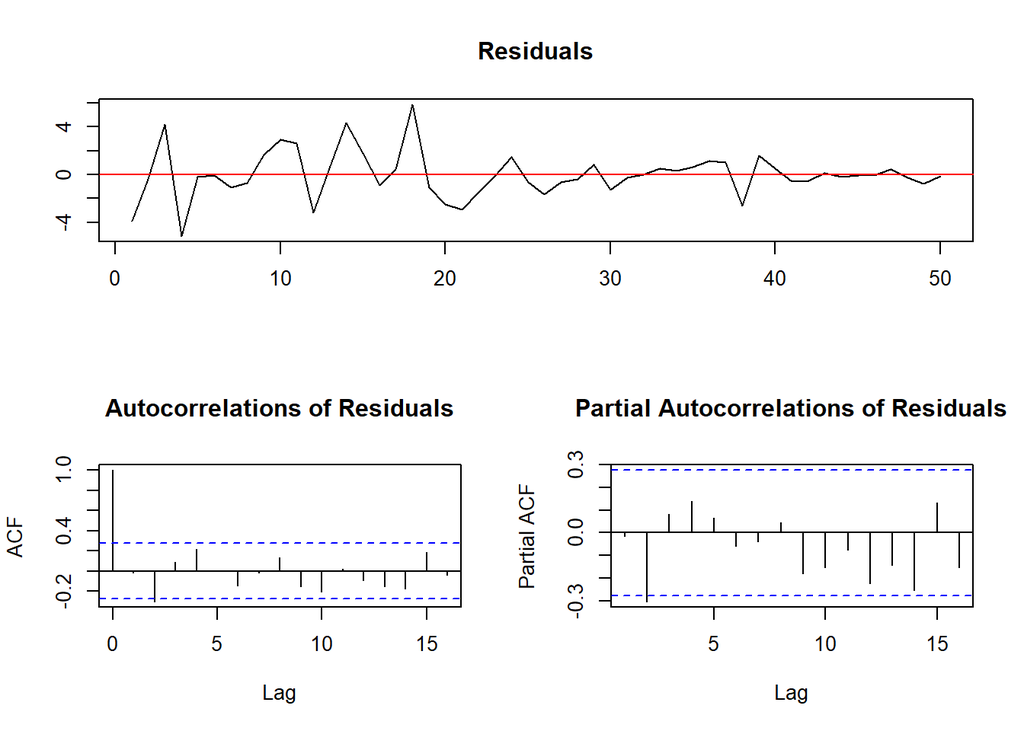

```r
plot(adf.SR)
```

```r
adf.LR <- ur.df(LR, type = "trend", selectlags = "BIC")
summary(adf.LR)
```

```
##
## ###############################################
## # Augmented Dickey-Fuller Test Unit Root Test #
## ###############################################
##
## Test regression trend
##
##
## Call:
## lm(formula = z.diff ~ z.lag.1 + 1 + tt + z.diff.lag)
##
## Residuals:
##      Min       1Q   Median       3Q      Max
## -1.98827 -0.56588  0.01596  0.52382  2.11148
##
## Coefficients:
##             Estimate Std. Error t value Pr(>|t|)
## (Intercept)  2.15109    0.75126   2.863  0.00629 **
## z.lag.1     -0.14546    0.05383  -2.702  0.00962 **
## tt          -0.04161    0.01422  -2.926  0.00532 **
## z.diff.lag   0.22899    0.13630   1.680  0.09973 .
## ---
## Signif. codes:  0 '***' 0.001 '**' 0.01 '*' 0.05 '.' 0.1 ' ' 1
##
## Residual standard error: 0.9486 on 46 degrees of freedom
## Multiple R-squared:  0.2194, Adjusted R-squared:  0.1685
## F-statistic:  4.31 on 3 and 46 DF,  p-value: 0.009247
##
##
## Value of test-statistic is: -2.702 3.1813 4.6141
##
## Critical values for test statistics:
##       1pct  5pct 10pct
## tau3 -4.04 -3.45 -3.15
## phi2  6.50  4.88  4.16
## phi3  8.73  6.49  5.47
```

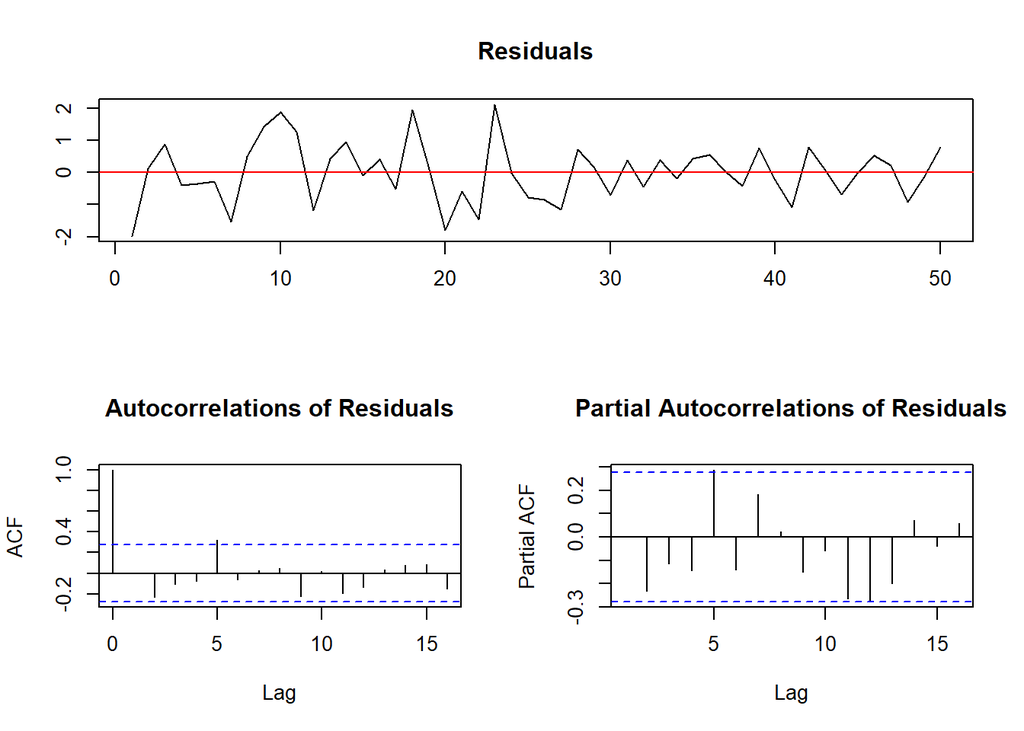

```r
plot(adf.LR)
```

```r
adf.DSR <- ur.df(diff(SR), type = "drift", selectlags = "BIC")
summary(adf.DSR)
```

```
##
## ###############################################
## # Augmented Dickey-Fuller Test Unit Root Test #
## ###############################################
##
## Test regression drift
##
##
## Call:
## lm(formula = z.diff ~ z.lag.1 + 1 + z.diff.lag)
##
## Residuals:
##     Min      1Q  Median      3Q     Max
## -4.9418 -0.8156 -0.2000  0.7298  5.6410
##
## Coefficients:
##             Estimate Std. Error t value Pr(>|t|)
## (Intercept)  -0.1535     0.2912  -0.527  0.60071
## z.lag.1      -1.4219     0.1930  -7.368 2.56e-09 ***
## z.diff.lag    0.3893     0.1350   2.884  0.00596 **
## ---
## Signif. codes:  0 '***' 0.001 '**' 0.01 '*' 0.05 '.' 0.1 ' ' 1
##
## Residual standard error: 2.031 on 46 degrees of freedom
## Multiple R-squared:  0.5895, Adjusted R-squared:  0.5716
## F-statistic: 33.02 on 2 and 46 DF,  p-value: 1.28e-09
##
##
## Value of test-statistic is: -7.368 27.1482
##
## Critical values for test statistics:
##       1pct  5pct 10pct
## tau2 -3.51 -2.89 -2.58
## phi1  6.70  4.71  3.86
```

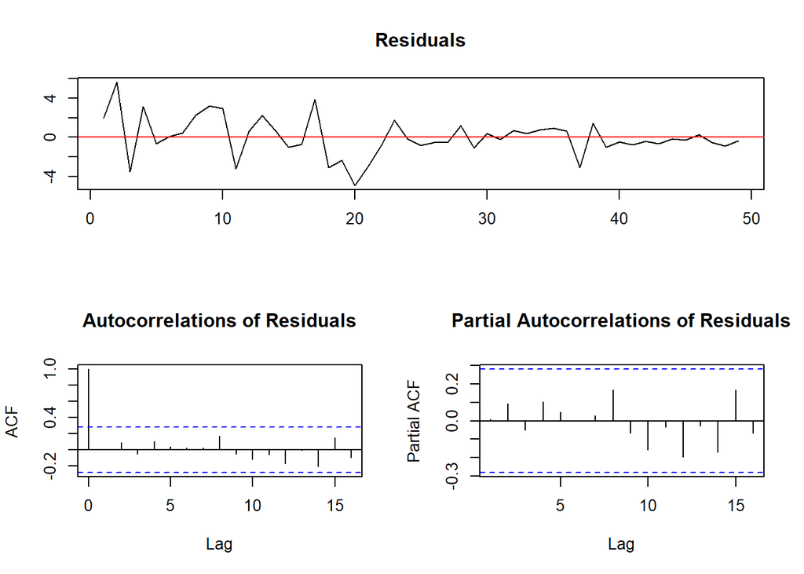

```r
plot(adf.DSR)
```

```r
adf.DLR <- ur.df(diff(LR), type = "drift", selectlags = "BIC")
summary(adf.DLR)
```

```
##
## ###############################################
## # Augmented Dickey-Fuller Test Unit Root Test #
## ###############################################
##
## Test regression drift
##
##
## Call:
## lm(formula = z.diff ~ z.lag.1 + 1 + z.diff.lag)
##
## Residuals:
##      Min       1Q   Median       3Q      Max
## -2.05033 -0.68729 -0.05778  0.59084  2.11227
##
## Coefficients:
##             Estimate Std. Error t value Pr(>|t|)
## (Intercept) -0.07546    0.14505  -0.520    0.605
## z.lag.1     -0.91178    0.17508  -5.208 4.36e-06 ***
## z.diff.lag   0.22397    0.14385   1.557    0.126
## ---
## Signif. codes:  0 '***' 0.001 '**' 0.01 '*' 0.05 '.' 0.1 ' ' 1
##
## Residual standard error: 1.006 on 46 degrees of freedom
## Multiple R-squared:  0.4049, Adjusted R-squared:  0.379
## F-statistic: 15.65 on 2 and 46 DF,  p-value: 6.537e-06
##
##
## Value of test-statistic is: -5.2079 13.578
##
## Critical values for test statistics:
##       1pct  5pct 10pct
## tau2 -3.51 -2.89 -2.58
## phi1  6.70  4.71  3.86
```

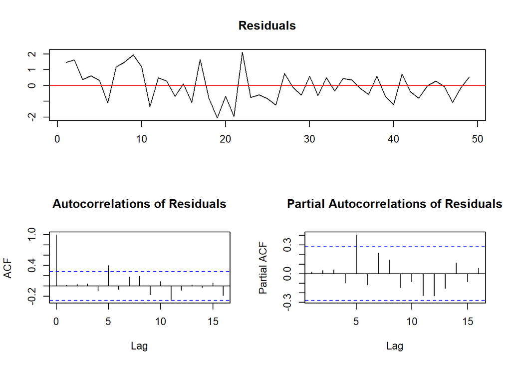

```r
plot(adf.DLR)
```

```r
#KPSS tests

kpss.SR = ur.kpss(SR, type = "tau", lags = "short")
summary(kpss.SR)
```

```
##
## #######################
## # KPSS Unit Root Test #
## #######################
##
## Test is of type: tau with 3 lags.
##
## Value of test-statistic is: 0.1666
##
## Critical value for a significance level of:
##                 10pct  5pct 2.5pct  1pct
## critical values 0.119 0.146  0.176 0.216
```

```r
kpss_LR = ur.kpss(LR, type = "tau", lags = "short")
summary(kpss_LR)
```

```
##
## #######################
## # KPSS Unit Root Test #
## #######################
##
## Test is of type: tau with 3 lags.
##
## Value of test-statistic is: 0.2113
##
## Critical value for a significance level of:
##                 10pct  5pct 2.5pct  1pct
## critical values 0.119 0.146  0.176 0.216
```

```r
kpss_DSR = ur.kpss(diff(SR), type = "mu", lags = "long")
summary(kpss_DSR)
```

```
##
## #######################
## # KPSS Unit Root Test #
## #######################
##
## Test is of type: mu with 10 lags.
##
## Value of test-statistic is: 0.2018
##
## Critical value for a significance level of:
##                 10pct  5pct 2.5pct  1pct
## critical values 0.347 0.463  0.574 0.739
```

```r
kpss_DLR = ur.kpss(diff(LR), type = "mu")
summary(kpss_DLR)
```

```
##
## #######################
## # KPSS Unit Root Test #
## #######################
##
## Test is of type: mu with 3 lags.
##
## Value of test-statistic is: 0.3434
##
## Critical value for a significance level of:
##                 10pct  5pct 2.5pct  1pct
## critical values 0.347 0.463  0.574 0.739
```

### c) Consider a VAR model wit ha constant of p and m, and determine the optimal lag length wit the VARselect() function of the vars package.

To test which is optimal, we need to test the residuals for first and second order autocorrelation with the Breusch-Godfrey LM test. The results of this test show that the p-value is suffuciently large to maintain teh VAR(1) specification.

The VAR printout itself tells us some other important information:

- The estimated roots of the characteristic polynomial are all smaller than 1 in absolute terms. Therefore, this VAR is stable.
- Both of the estimated equations of VAR(1) are reasonable as they have large and significant adjusted R^2 values.

```r
#library(vars)

data = cbind(SR, LR)
VARselect(data, type = "const")
```

```
## $selection
## AIC(n)  HQ(n)  SC(n) FPE(n)
##      9      1      1      1
##
## $criteria
##                1         2         3        4         5         6         7
## AIC(n) 0.5391064 0.5806811 0.6373563 0.809357 0.6990466 0.6786749 0.6972732
## HQ(n)  0.6300956 0.7323298 0.8496645 1.082325 1.0326738 1.0729615 1.1522194
## SC(n)  0.7873449 0.9944119 1.2165795 1.554073 1.6092545 1.7543751 1.9384658
## FPE(n) 1.7153099 1.7913150 1.9033854 2.276981 2.0627437 2.0557779 2.1449807
##                8         9        10
## AIC(n) 0.5445278 0.4602149 0.6038779
## HQ(n)  1.0601335 1.0364800 1.2408026
## SC(n)  1.9512127 2.0323922 2.3415475
## FPE(n) 1.9018050 1.8247635 2.2279959
```

```r
#Testing residuals

var1 <- VAR(data, p = 1, type = "const")

serial.test(var1, lags.bg = 2, type = "BG")
```

```
##
##  Breusch-Godfrey LM test
##
## data:  Residuals of VAR object var1
## Chi-squared = 9.4965, df = 8, p-value = 0.3022
```

```r
summary(var1)
```

```
##
## VAR Estimation Results:
## =========================
## Endogenous variables: SR, LR
## Deterministic variables: const
## Sample size: 51
## Log Likelihood: -155.585
## Roots of the characteristic polynomial:
## 0.9876 0.3175
## Call:
## VAR(y = data, p = 1, type = "const")
##
##
## Estimation results for equation SR:
## ===================================
## SR = SR.l1 + LR.l1 + const
##
##       Estimate Std. Error t value Pr(>|t|)
## SR.l1   0.3676     0.2080   1.767  0.08356 .
## LR.l1   0.6801     0.2464   2.760  0.00816 **
## const  -0.5915     0.6791  -0.871  0.38808
## ---
## Signif. codes:  0 '***' 0.001 '**' 0.01 '*' 0.05 '.' 0.1 ' ' 1
##
##
## Residual standard error: 1.989 on 48 degrees of freedom
## Multiple R-Squared: 0.8219,  Adjusted R-squared: 0.8145
## F-statistic: 110.7 on 2 and 48 DF,  p-value: < 2.2e-16
##
##
## Estimation results for equation LR:
## ===================================
## LR = SR.l1 + LR.l1 + const
##
##       Estimate Std. Error t value Pr(>|t|)
## SR.l1  0.04567    0.10966   0.416    0.679
## LR.l1  0.93749    0.12988   7.218 3.41e-09 ***
## const  0.03489    0.35797   0.097    0.923
## ---
## Signif. codes:  0 '***' 0.001 '**' 0.01 '*' 0.05 '.' 0.1 ' ' 1
##
##
## Residual standard error: 1.049 on 48 degrees of freedom
## Multiple R-Squared: 0.9303,  Adjusted R-squared: 0.9274
## F-statistic: 320.5 on 2 and 48 DF,  p-value: < 2.2e-16
##
##
##
## Covariance matrix of residuals:
##       SR   LR
## SR 3.958 1.62
## LR 1.620 1.10
##
## Correlation matrix of residuals:
##        SR     LR
## SR 1.0000 0.7765
## LR 0.7765 1.0000
```

### d) Use the estimated VAR(1) model to forecast ST and LR 1-4 years ahead.

The dark and light blue bands represent 80% and 95% rpediction bands respectively.

```r
#library(forecast)

var1_ea <- forecast(var1, h = 4)

print(var1_ea)
```

```
## SR
##      Point Forecast     Lo 80    Hi 80     Lo 95    Hi 95
## 2022      0.4253596 -2.124218 2.974937 -3.473882 4.324602
## 2023      0.5330142 -2.556413 3.622441 -4.191856 5.257885
## 2024      0.5490090 -2.905246 4.003264 -4.733818 5.831836
## 2025      0.5361235 -3.221987 4.294234 -5.211411 6.283658
##
## LR
##      Point Forecast       Lo 80    Hi 80      Lo 95    Hi 95
## 2022       1.423667  0.07980634 2.767528 -0.6315906 3.478925
## 2023       1.388988 -0.51746862 3.295445 -1.5266858 4.304662
## 2024       1.361394 -0.97133100 3.694118 -2.2062008 4.928988
## 2025       1.336255 -1.34920087 4.021710 -2.7707951 5.443304
```

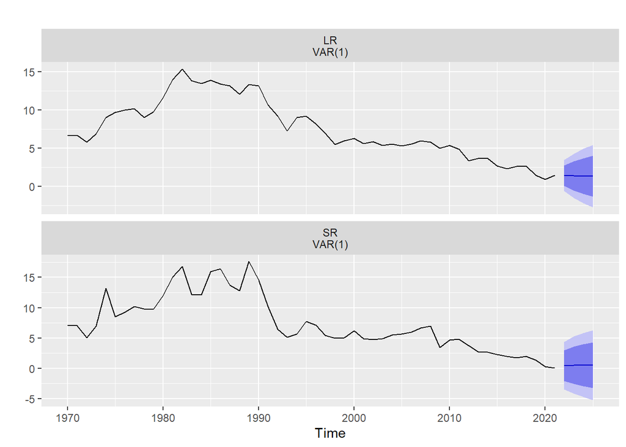

```r
autoplot(var1_ea)
```

### e) Use the VAR(1) model to test for Granger causality between the SR and LR at the 5% significance level.

This test confirms the intuitive relationship between the LR and SR interest rate. The null hypothesis of the Granger causality tests is that X has no impact on Y for both the F-test and Chi-square tests.

Both tests the LR is causing SR (i.e. LR -> SR) at the 1% level, but SR is not causing LR (i.e. SR -/> LR). Therefore, this implies SR is an endogenous variable, whereas LR appears to be exogenous.

Occasionally, the F and Chi-square contradict and you’ll need to make a judgement call on which test to rely on: the prior assumes normality while the other does not.

To help make this judgement, conduct a normality test on the residuals. The p-value of the JB test is very small, indicating normality can be rejected, which is attributable to both skewness and kurtosis. In a situation where the chi-square and f-tests contradict, you would want to lean on the chi-square test because normality does not apply.

```r
# library(bruceR)
granger_causality(var1)
```

```
##
## Granger Causality Test (Multivariate)
##
## F test and Wald χ² test based on VAR(1) model:
## ───────────────────────────────────────────────────────
##                  F df1 df2     p     Chisq df     p
## ───────────────────────────────────────────────────────
##  ---------
##  SR <= LR     7.62   1  48  .008 **   7.62  1  .006 **
##  SR <= ALL    7.62   1  48  .008 **   7.62  1  .006 **
##  ---------
##  LR <= SR     0.17   1  48  .679      0.17  1  .677
##  LR <= ALL    0.17   1  48  .679      0.17  1  .677
## ───────────────────────────────────────────────────────
```

```r
normality.test(var1)
```

```
## $JB
##
##  JB-Test (multivariate)
##
## data:  Residuals of VAR object var1
## Chi-squared = 22.256, df = 4, p-value = 0.0001782
##
##
## $Skewness
##
##  Skewness only (multivariate)
##
## data:  Residuals of VAR object var1
## Chi-squared = 9.662, df = 2, p-value = 0.007978
##
##
## $Kurtosis
##
##  Kurtosis only (multivariate)
##
## data:  Residuals of VAR object var1
## Chi-squared = 12.594, df = 2, p-value = 0.001842
```